# Empirical Drug Parameter (DK) Prediction

# Descriptive statistics

## Boxplots and Summary statistics

```
        base          MW             CsE              CsP                 Pka             logP
 base     :37   Min.   :247.2   Min.   : 0.220   Min.   :  0.00711   Min.   : 2.65   Min.   :-1.1900
 na       :56   1st Qu.:293.2   1st Qu.: 0.906   1st Qu.:  0.17000   1st Qu.: 9.81   1st Qu.:-1.1900
 potassium: 0   Median :312.5   Median : 2.500   Median :  1.05000   Median :10.11   Median : 1.7060
 salt     : 9   Mean   :370.3   Mean   : 7.351   Mean   : 24.47005   Mean   :10.33   Mean   : 0.9237
 sodium   : 0   3rd Qu.:449.4   3rd Qu.:12.400   3rd Qu.:  4.98000   3rd Qu.:13.32   3rd Qu.: 1.7060
                Max.   :534.5   Max.   :57.600   Max.   :165.60000   Max.   :17.91   Max.   : 3.8000
       DK              log10DK
 Min.   :0.001656   Min.   :-2.7810
 1st Qu.:0.007888   1st Qu.:-2.1031
 Median :0.024074   Median :-1.6185
 Mean   :0.062799   Mean   :-1.6121
 3rd Qu.:0.074706   3rd Qu.:-1.1267
 Max.   :0.692629   Max.   :-0.1595
        base         MW             CsE              CsP              Pka              logP
 base     :5   Min.   :229.3   Min.   : 0.080   Min.   : 0.080   Min.   : 4.800   Min.   :-1.400
 na       :1   1st Qu.:286.3   1st Qu.: 1.150   1st Qu.: 0.080   1st Qu.: 4.800   1st Qu.: 1.335
 potassium:1   Median :412.9   Median : 6.504   Median : 2.553   Median : 7.610   Median : 1.462
 salt     :1   Mean   :369.7   Mean   :19.340   Mean   :16.268   Mean   : 7.101   Mean   : 1.367
 sodium   :6   3rd Qu.:441.4   3rd Qu.:26.796   3rd Qu.: 2.553   3rd Qu.: 8.200   3rd Qu.: 2.200
               Max.   :482.5   Max.   :75.837   Max.   :78.120   Max.   :14.290   Max.   : 2.200
       DK               log10DK
 Min.   :0.0004328   Min.   :-3.364
 1st Qu.:0.0017451   1st Qu.:-2.824
 Median :0.0059093   Median :-2.228
 Mean   :0.0269988   Mean   :-2.166
 3rd Qu.:0.0177921   3rd Qu.:-1.757
 Max.   :0.1592378   Max.   :-0.798
```

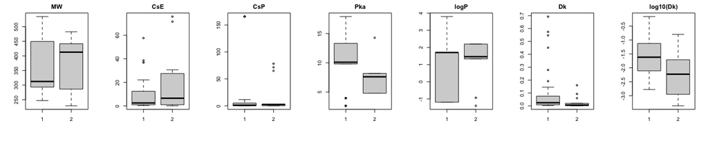

- It seems like fitting linear regression using `log10(Dk)` is better than using the raw `Dk` variable, because the former is distributed more homogeneously.

## Spearman correlation plot of variables

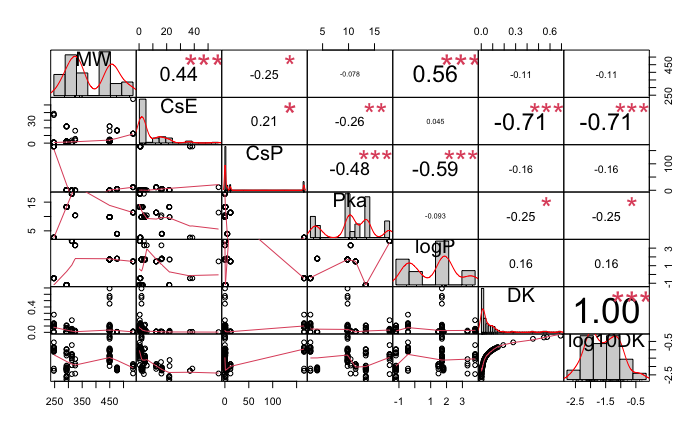

- Numbers in the upper triangular cells are Spearman coefficient between two variables
- `CsE` highly correlated with `Dk`, `Pka` moderately correlated with `DK`

# Linear regression prediction model

## Transformation of Variables

```r
#####################################################
# Pearson correlation of transformed variables and log10(DK)
# raw, power, logarithm, reciprocal transformation are considered
#####################################################

corr_trans_result <- data.table(var = rep(c("MW", "CsE", "CsP", "Pka", "logP"), each = 4),
                                trans = rep(c("raw", "power", "logarithm", "reciprocal"), 5),
                                corr = c(0))

for(varname in c("MW","CsE","CsP","Pka","logP")){
  raw <- train[[varname]]
  corr_trans_result[var == varname & trans == "raw", "corr"]        <- cor(raw, train$log10DK)
  corr_trans_result[var == varname & trans == "power", "corr"]      <- cor(exp(raw), train$log10DK)
  corr_trans_result[var == varname & trans == "logarithm", "corr"]  <- cor(log(raw), train$log10DK)
  corr_trans_result[var == varname & trans == "reciprocal", "corr"] <- cor(1/raw, train$log10DK)
}

corr_trans_result
```

| var | trans | corr |
| --- | --- | --- |
| MW | raw | -0.03208177 |
| MW | power | -0.20750375 |
| MW | logarithm | -0.03075520 |
| MW | reciprocal | 0.03690221 |
| CsE | raw | -0.60051148 |
| CsE | power | -0.13452608 |
| CsE | logarithm | -0.67367673 |
| CsE | reciprocal | 0.44267935 |
| CsP | raw | 0.24759082 |
| CsP | power | 0.26529736 |

[output cut: 10 more lines]

- For **Molecular Weight (`MW`)**, power gives the largest (in absolute value) correlation (0.207), but then the scale is too large. **raw** variable is considered instead.
- For **solubility in excipient (`CsE`)**, **logarithm** gives the largest (in absolute value) correlation (0.673)
- For **solubility in PBS (`CsP`)**, power gives the largest (in absolute value) correlation (0.265), and **raw** gives the second largest correlation (0.247), but **raw*** is considered for simplicity
- For **`Pka`**, **reciprocal** gives the largest (in absolute value) correlation (0.171), but **raw** can be considered also.
- For **`LogP`**, **raw** variable gives the largest (in absolute value) correlation (0.155)

## Linear regression including all variables

```r
fit.lm.all <- lm(log10DK ~ MW + I(log10(CsE)) + CsP + Pka + logP, data = train)
summary(fit.lm.all)
```

```
Call:
lm(formula = log10DK ~ MW + I(log10(CsE)) + CsP + Pka + logP,
    data = train)

Residuals:
     Min       1Q   Median       3Q      Max
-0.66770 -0.18880 -0.04639  0.13126  1.02857

Coefficients:
               Estimate Std. Error t value Pr(>|t|)
(Intercept)   -2.051583   0.326770  -6.278 9.91e-09 ***
MW             0.002923   0.000568   5.147 1.41e-06 ***
I(log10(CsE)) -0.906682   0.058664 -15.455  < 2e-16 ***
CsP            0.002788   0.001145   2.434   0.0168 *
Pka           -0.031957   0.013377  -2.389   0.0189 *
logP           0.048719   0.022192   2.195   0.0305 *
---
Signif. codes:  0 ‘***’ 0.001 ‘**’ 0.01 ‘*’ 0.05 ‘.’ 0.1 ‘ ’ 1

Residual standard error: 0.3072 on 96 degrees of freedom
Multiple R-squared:  0.7495,    Adjusted R-squared:  0.7364
F-statistic: 57.43 on 5 and 96 DF,  p-value: < 2.2e-16
```

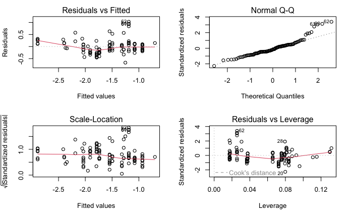

```r
par(mfrow = c(2,2))
plot(fit.lm.all)
```

## Prediction Model

$$\text{log}_{10}(\text{Dk}) = -2.052 +
2.923*10^{-3} * \text{MW} - 9.067 * 10^{-1} *
\text{log}_{10}(\text{CsE}) + 2.788*10^{-3} * \text{CsP} - 3.196*10^{-2}
* \text{Pka} + 4.872 * 10^{-2} * \text{logP}$$

# Figures

### Figure2: Observed vs Predicted log10DK (DK) values scatter plot

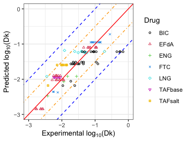

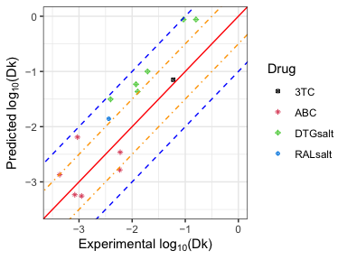

### Figure S1: Prediction results by drug type

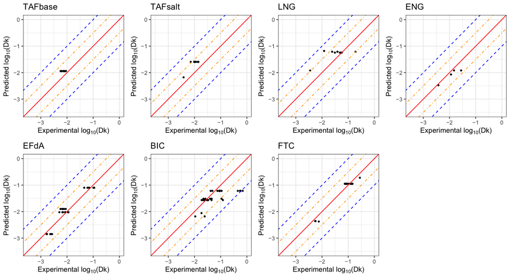

### Figure S3: Machine Learning approaches

We also considered Support Vector Machine and Random Forest models to improve the prediction quality, but there were no significant improvement compared to Linear Regression model. Therefore, we ended up with using Linear Regression model as our final prediction model.

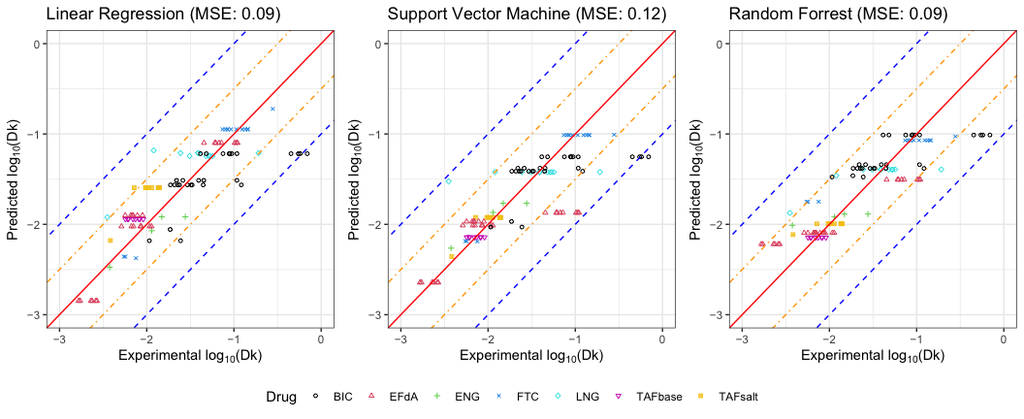